# Math 578B :: Fall 2015 :: Take-home midterm

Peter Ralph

due 29 September

**1.** Let $N$ be a Poisson random variable with mean $\lambda$, and, given $N$, let $X_1, \ldots, X_N$ be iid random variables in the discrete set $\mathcal{A}$ with distribution $\pi$. For each $1\le k \le N$ let $X_k(t)$ be an independent continuous-time Markov chain on $\mathcal{A}$ with initial state $X_k(0)=X_k$, and suppose that the Markov chains have transition rate matrix $Q$ with $\sum_a \pi(a) Q_{ab} = 0$ for each $b$. (In other words, if the chain is in state $a$, it waits there for an exponential amount of time with mean $-1/Q_{aa}$, then jumps to state $b$ with probability $Q_{ab}/(-Q_{aa})$.) Show that for each $t \ge 0$ and each state $x \in \mathcal{A}$, that $N_t(a) = \#\{ k : X_k(t) = a \}$ is Poisson distributed with mean $\lambda \pi(a)$.

**Solution:**

Here $\pi$ is a stationary distribution for the Markov chain: $\pi^T e^{tQ} = \sum_n \pi^T Q^n t^n / n! = \pi^T$. By stationarity, $X_k(t) \sim \pi$ for each $k$ and each $t$. By Poisson coloring, the result follows.

**2.** Let $S_n$ denote the set of permutations on $n$ elements, and for $s \in S_n$ let $c(s)$ denote the number of cycles of $s$. To perform a statistical test, it is desired to sample from the distribution
$$\pi_\alpha(s) = \frac{ c(s)^\alpha }{ \sum_{u \in S_n} c(u)^\alpha },$$
for a parameter $\alpha \ge 0$.

1. Design and implement a Markov chain whose stationary distribution is $\pi_\alpha$.

**Solution:**

Represent a permutation $s$ by $(s(1),\ldots,s(n))$. The moves we will use exchanges $s(j)$ and $s(k)$, with $j$ and $k$ uniformly chosen. It is clear this is symmetric, so we need only calculate the Hastings ratio.

```r
move <- function (s) {
    jk <- sample.int(length(s),2,replace=TRUE)
    s[jk] <- rev(s[jk])
    return(s)
}
cycles <- function (s) {
    ncycles <- 1
    now <- 1
    done <- c(TRUE,rep(FALSE,length(s)-1))
    while (any(!done)) {
        now <- s[now]
        if (done[now]) {
            ncycles <- ncycles + 1
            now <- min(which(!done))
        }
        done[now] <- TRUE
    }
    return(ncycles)
}
mcmc <- function (s,nsteps, alpha) {
    ss <- matrix(0,nrow=length(s),ncol=nsteps)
    ncycles <- cycles(s)
    for (k in 1:nsteps) {
        ss[,k] <- s
        snew <- move(s)
        newcycles <- cycles(snew)
        if (runif(1) <= (newcycles/ncycles)^alpha) {
            s <- snew
            ncycles <- newcycles
        }
    }
    return(ss)
}
```

2. Check that your Markov chain has the correct stationary distribution by implementing it and comparing samples from it after a large number of steps to exact calculations for $\alpha=3$ and $n=2,3,4$.

Here are all the possible permutations.

```r
n <- 4
alpha <- 3
perms <- rbind(1:n,permute::allPerms(n)) # allPerms does *not* include the identity for some reason !?!?!
perm.cycles <- apply(perms,1,cycles)
perm.probs <- perm.cycles^alpha/sum(perm.cycles^alpha)
mcrun <- mcmc(sample.int(n),nsteps=100000,alpha=alpha)
mcrun <- mcmc(mcrun[,ncol(mcrun)],nsteps=100000,alpha=alpha)
cbind( theory=perm.probs,
      simulation=table(factor(apply(mcrun,2,paste,collapse=''),levels=apply(perms,1,paste,collapse='')))/ncol(mcrun)
  )
```

```
##        theory simulation
## 1234 0.200000    0.19893
## 1243 0.084375    0.08314
## 1324 0.084375    0.08669
## 1342 0.025000    0.02607
## 1423 0.025000    0.02638
## 1432 0.084375    0.08831
## 2134 0.084375    0.08525
## 2143 0.025000    0.02549
## 2314 0.025000    0.02432
## 2341 0.003125    0.00294
## 2413 0.003125    0.00333
## 2431 0.025000    0.02504
## 3124 0.025000    0.02583
## 3142 0.003125    0.00299
## 3214 0.084375    0.08327
## 3241 0.025000    0.02466
## 3412 0.025000    0.02552
## 3421 0.003125    0.00304
## 4123 0.003125    0.00319
## 4132 0.025000    0.02468
## 4213 0.025000    0.02385
## 4231 0.084375    0.08122
## 4312 0.003125    0.00317
## 4321 0.025000    0.02269
```

**Solution:**

3. Use your Markov chain to estimate for $n=100$ and $\alpha=3$ the distribution of the number of cycles, as well as
   $$\sum_{s \in S_n} \pi(s) c(s)$$
   and
   $$\sum_{s \in S_n} \pi(s) c(s)^2 .$$
   Make sure to justify why you're getting a good estimate.

**Solution:**

Here's the chain and the autocorrelation function for the first slot

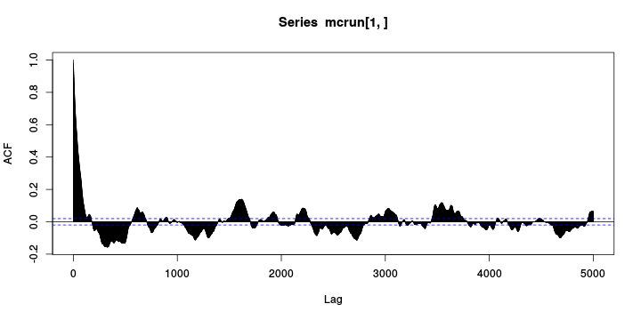

```r
n <- 100
alpha <- 3
mcrun <- mcmc(sample.int(n),nsteps=1000,alpha=alpha)
mcrun <- mcmc(mcrun[,ncol(mcrun)],nsteps=10000,alpha=alpha)
mcrun.cycles <- apply(mcrun,2,cycles)
plot(acf(mcrun[1,],lag.max=ncol(mcrun)/2))
```

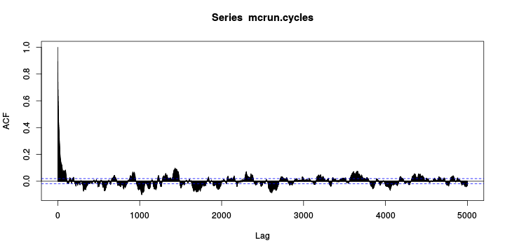

```r
plot(acf(mcrun.cycles,lag.max=ncol(mcrun)/2))
```

The correlation decays quickly, so we're getting a good number of independentish samples (this could be more quantitative). Here are the estimates:

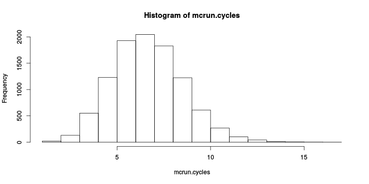

```r
hist(mcrun.cycles)
```

```r
# mean number of cycles
mean(mcrun.cycles)
```

```
## [1] 7.1423
```

```r
# mean squared number of cycles
mean(mcrun.cycles^2)
```

```
## [1] 54.6009
```

**3.** Here is a simplified model of a "cut-and-paste" DNA transposon. The *transposon* is a 3kb segment of DNA that behaves as follows. Suppose it is inserted at position $x$ in a single chromosome of a diploid. Each meiosis, with probability $\mu$, it *transposes*: it is removed from location $x$, then inserted at two other locations, say, $y$ and $z$, (randomly chosen from the genome). Any insertions present then each have probability $1/2$ of being passed on to the chromosome inherited by the offspring. (So, if the two parental chromosomes have insertions at $n$ locations, the number of insertions inherited by the offspring's chromosome is Binomial($n$,$1/2$): this ignores the fact that both parents might have insertions at the same location, but we check this assumption below.) Suppose we are studying this transposon in a diploid population of $N$ individuals, in which each generation, $N$ random pairs are chosen to mate to produce the next generation. For simplicity, suppose the organism has a single chromosome of length $3 \times 10^9$ and that $\mu=0.05$.

1. Simulate the process, beginning with a single copy of the transposon at one location. (For efficiency, you might want to just keep track of the locations of the transposon insertions, ignoring any potential overlap of the 3kb segments.) Show using your simulations with $N=1000$ that
   - the transposon might not spread,
   - but if it does, the number of copies grows exponentially, but
   - even so, there are very few locations in the genome at which an insertion is common in the population.

**Solution:**

```r
mu <- 0.05
# individuals are numeric vectors of insert locations
reproduce <- function (ind) {
    jumped <- ( rbinom(length(ind),size=1,prob=mu)>0 )
    newind <- c( ind[!jumped], runif(2*sum(jumped)) )
    return( newind[ rbinom(length(newind),size=1,prob=1/2)>0 ] )
}
sim.gen <- function (pop,N=length(pop)) {
    parents <- cbind( mom=sample.int(length(pop),N,replace=TRUE), pop=sample.int(N,length(pop),replace=TRUE))
    newpop <- vector(mode="list",length=N)
    for (k in 1:N) {
        newpop[[k]] <- reproduce( unique(unlist(pop[parents[k,]])) )
    }
    return(newpop)
}
sim.gens <- function (pop,n,max.copies=Inf,count.copies=FALSE) {
    if (count.copies) {
        counts <- numeric(n)
        counts[1] <- length(unlist(pop))
    }
    for (k in 2:n) {
        pop <- sim.gen(pop)
        n.copies <- length(unlist(pop))
        if (count.copies) {
            counts[k] <- n.copies
        }
        if ( n.copies==0 || n.copies>max.copies ) {
            break;
        }
    }
    if (count.copies) { pop <- counts }
    attr(pop,"gen") <- k
    return(pop)
}
```

First, let's find out the probability that it takes off.

```r
N <- 1e2
init.pop <- list( c(0.5), numeric(0) )[c(1,rep(2,N-1))]
nreps <- 1000
ngens <- 1000
max.copies <- 100
many.pops <- replicate( nreps, sim.gens(init.pop,ngens,max.copies=max.copies), simplify=FALSE )
gens <- sapply( many.pops, attr, "gen" )
copies <- sapply( lapply(many.pops,unlist), length )
prob.estab <- mean(copies>0)
```

The probability that it reaches 100 copies is 0.049; the chance it hits zero after this is very small.

Now let's look at a few simulations where it did take off:

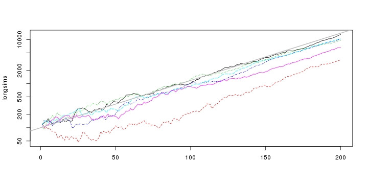

```r
usethese <- sample(which(copies>0),6)
longsims <- sapply( many.pops[usethese], sim.gens, n=200, max.copies=1e5, count.copies=TRUE )
matplot(longsims,type='l',log='y')
abline(log10(100),log10(1+mu/2),col='grey',lwd=2)
```

Yup; that's exponential growth.

Now, let's look at frequency per location.

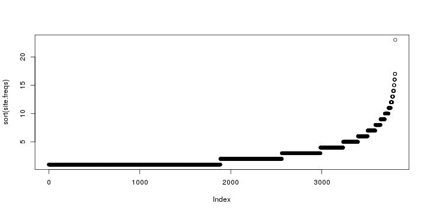

```r
N <- 1e3
while( TRUE ) {
    longsim <- sim.gens( many.pops[[usethese[1]]], n=200, max.copies=1e5 )
    if ( length(unlist(longsim))!=0 ) { break }
}
site.freqs <- table( unlist(longsim) )
plot(sort(site.freqs))
```

2. Explain, mathematically, the observation that the number of copies grows exponentially: Use a branching process model for the *total number* of transposon copies in the population to find the mean number of copies present after $t$ generations.

**Solution:**

Consider a transposon copy. It is chosen to reproduce a Poisson(2) number of times; each time, the number of offspring insertions it leaves behind is either a Binomial(2,1/2) (with probability $\mu$) or Binomial(1,1/2) (otherwise). The probability that it has $k$ offspring is messy, but the mean number of offspring is $2 \times ( \mu + (1-\mu)/2 ) = 1+\mu$, so the mean total number of copies is $(1+\mu)^t$.

3. Explain, mathematically, the observation that each insertion site is infrequently used in the population. Use a branching process model for the number of transposon copies *at location $x$* in the population and the identity ${\mathbb{P}}\{X>0\} \le {\mathbb{E}}[X]$ (for nonnegative $X$) to find an upper bound on the probability that a new insertion at $x$ will persist in the population for at least $t$ generations.

**Solution:**

The number of offspring is now Poisson($1-\mu$). Using the bound, the probability a site lives for $t$ generations is no more than $(1-\mu)^t$.

4. Suppose a single transposon with transposition rate $\mu=10^{-2}$ is introduced to a population of $10^7$ individuals. If it spreads, how long do you estimate it will be until 10% of the genome of a typical individual is composed of transposons?

**Solution:**

The total number of non-transposon base pairs is $3 \times 10^9 \times 2 \times 10^7 = 6 \times 10^{16}$; Using *b*, the total number of transposon base pairs is $(1+\mu)^t \times 3 \times 10^3$; setting this equal to 10% of the total number and taking logarithms, we have that $t = \log( 2 \times 10^{12} )/\log(1+\mu)$, or $t=2846.5554276$ generations.